# Ecoblitz Weather & Flowering Phenology

**Alec Brooks, Seth Miller, Eriko Sakamura**  
*April 16, 2025*

# Precipitation Analysis

## Stats

ANOVA Fall (RAIN_INCHES ~ factor(YEAR))

|  | Df | Sum Sq | Mean Sq | F value | Pr(>F) |
| --- | --- | --- | --- | --- | --- |
| factor(YEAR) | 2 | 0.2255026 | 0.1127513 | 5.503249 | 0.0047644 |
| Residuals | 186 | 3.8107937 | 0.0204881 | NA | NA |

TukeyHSD Fall (RAIN_INCHES ~ factor(YEAR))

|  | diff | lwr | upr | p adj |
| --- | --- | --- | --- | --- |
| 2022-2021 | -0.0142857 | -0.0745405 | 0.0459691 | 0.8413774 |
| 2023-2021 | 0.0650794 | 0.0048246 | 0.1253341 | 0.0308070 |
| 2023-2022 | 0.0793651 | 0.0191103 | 0.1396199 | 0.0060689 |

ANOVA Spring (RAIN_INCHES ~ factor(YEAR))

|  | Df | Sum Sq | Mean Sq | F value | Pr(>F) |
| --- | --- | --- | --- | --- | --- |
| factor(YEAR) | 2 | 138.9410 | 69.470484 | 48.7219 | 0 |
| Residuals | 183 | 260.9319 | 1.425858 | NA | NA |

TukeyHSD Spring (RAIN_INCHES ~ factor(YEAR))

|  | diff | lwr | upr | p adj |
| --- | --- | --- | --- | --- |
| 2022-2021 | 0.0983871 | -0.408382 | 0.6051562 | 0.8905596 |
| 2023-2021 | 1.8806452 | 1.373876 | 2.3874143 | 0.0000000 |
| 2023-2022 | 1.7822581 | 1.275489 | 2.2890272 | 0.0000000 |

## Plots

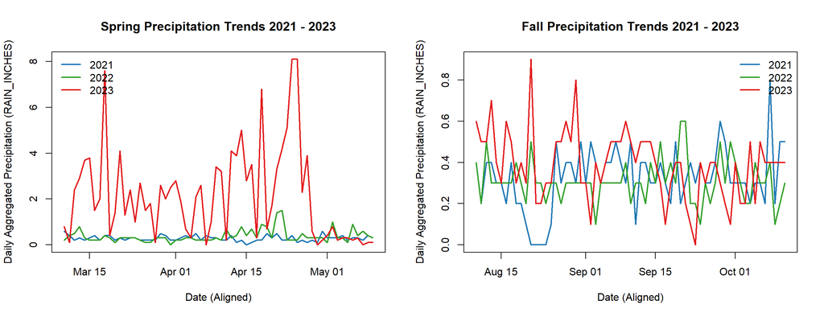

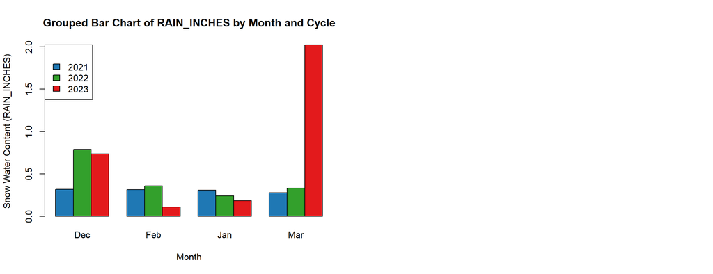

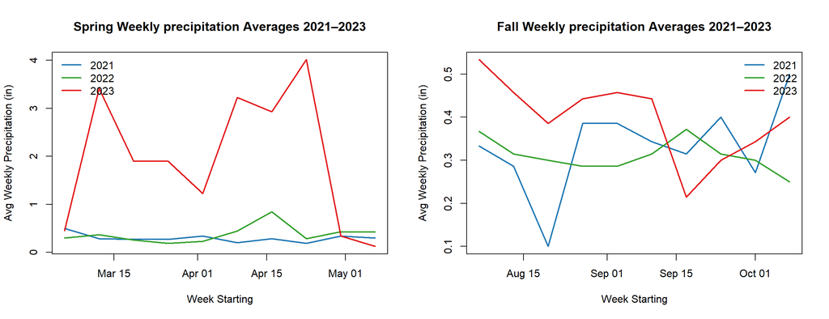

## Conclusion

I dun know.

# Winter Snow Analysis

## Stats

Correlation Matrix SNOW_WC ~ TEMP_AVERAGE

| Year | Fall | Winter | Spring |
| --- | --- | --- | --- |
| 2021 | -0.4873247 | 0.3311611 | -0.6954612 |
| 2022 | NA | 0.0572723 | 0.0249896 |
| 2023 | 0.1379338 | -0.3367648 | -0.1822224 |

ANOVA Fall (SNOW_WC ~ factor(YEAR))

|  | Df | Sum Sq | Mean Sq | F value | Pr(>F) |
| --- | --- | --- | --- | --- | --- |
| factor(YEAR) | 2 | 1.061058 | 0.5305291 | 49.33138 | 0 |
| Residuals | 186 | 2.000317 | 0.0107544 | NA | NA |

TukeyHSD Fall (SNOW_WC ~ factor(YEAR))

|  | diff | lwr | upr | p adj |
| --- | --- | --- | --- | --- |
| 2022-2021 | -0.0095238 | -0.0531787 | 0.0341311 | 0.8639202 |
| 2023-2021 | 0.1539683 | 0.1103133 | 0.1976232 | 0.0000000 |
| 2023-2022 | 0.1634921 | 0.1198371 | 0.2071470 | 0.0000000 |

ANOVA Winter (SNOW_WC ~ factor(YEAR))

|  | Df | Sum Sq | Mean Sq | F value | Pr(>F) |
| --- | --- | --- | --- | --- | --- |
| factor(YEAR) | 2 | 9359.261 | 4679.63025 | 222.0825 | 0 |
| Residuals | 234 | 4930.752 | 21.07159 | NA | NA |

TukeyHSD Winter (SNOW_WC ~ factor(YEAR))

|  | diff | lwr | upr | p adj |
| --- | --- | --- | --- | --- |
| 2022-2021 | 6.598734 | 4.875964 | 8.321505 | 0 |
| 2023-2021 | 15.343038 | 13.620267 | 17.065809 | 0 |
| 2023-2022 | 8.744304 | 7.021533 | 10.467074 | 0 |

ANOVA Spring (SNOW_WC ~ factor(YEAR))

|  | Df | Sum Sq | Mean Sq | F value | Pr(>F) |
| --- | --- | --- | --- | --- | --- |
| factor(YEAR) | 2 | 39489.240 | 19744.620 | 1124.153 | 0 |
| Residuals | 183 | 3214.211 | 17.564 | NA | NA |

TukeyHSD Spring (SNOW_WC ~ factor(YEAR))

|  | diff | lwr | upr | p adj |
| --- | --- | --- | --- | --- |
| 2022-2021 | 5.272581 | 3.493958 | 7.051203 | 0 |
| 2023-2021 | 33.206452 | 31.427829 | 34.985074 | 0 |
| 2023-2022 | 27.933871 | 26.155249 | 29.712493 | 0 |

## Plots

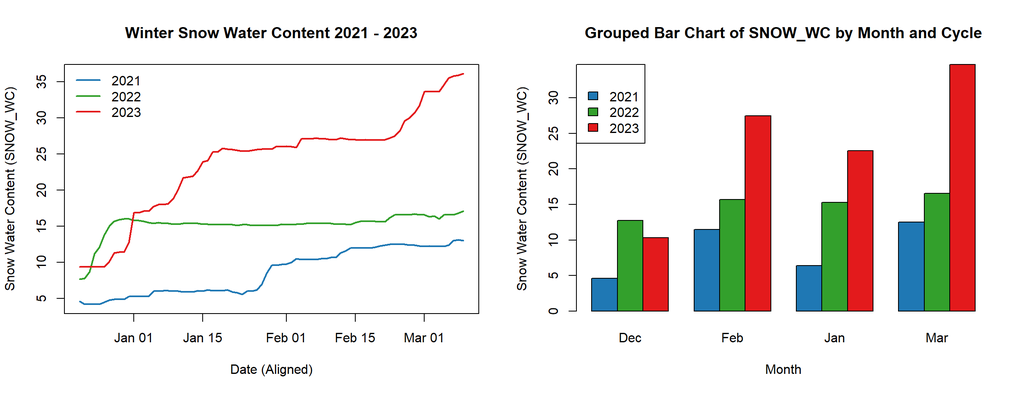

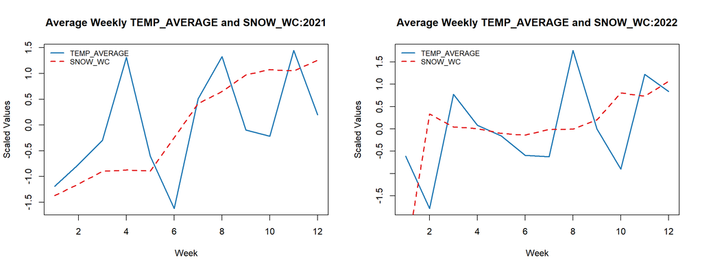

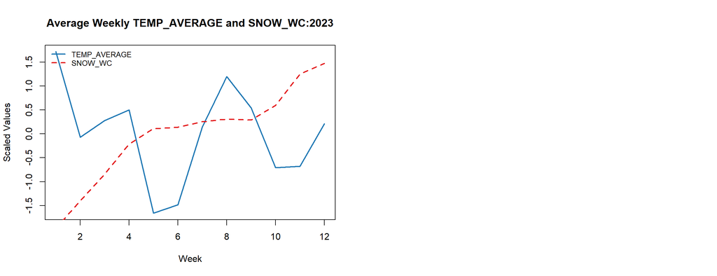

## Conclusion

The results of our ANOVA and Tukey HSD tests indicate that snow water content (SNOW_WC) was significantly different across the years 2021, 2022, and 2023, with 2023 showing a much higher snowfall than the previous two years. The extremely small p-values (p < 2e-16) suggest that these differences are not random chance but rather a real and substantial change in snowfall patterns. The statistical significance of YEAR used as a predictor variable indicates that winter snowpack and temperatures play a critical role in shaping ecological conditions for the following spring bloom season, particularly through nighttime low temperatures that regulate seed germination and soil moisture from slow snowmelt. Given that spring bloomers are more sensitive to these factors, the sharp increase in snowpack and the colder temperatures in 2023 likely created conditions that influenced which species germinated and overall blooming cycles. In contrast, fall bloomers are better adapted to extreme conditions, including drought and high temperatures, meaning their germination remains more stable over multiple years despite fluctuations in winter precipitation and temperatures. These findings reinforce that winter conditions primarily influence spring bloom dynamics, while fall species tend to exhibit greater resilience to annual weather variation.

# Temperature Analysis

## Seasonal

### Stats

ANOVA Spring TEMP_AVERAGE ~ factor(YEAR))

|  | Df | Sum Sq | Mean Sq | F value | Pr(>F) |
| --- | --- | --- | --- | --- | --- |
| factor(YEAR) | 2 | 444.0833 | 222.04167 | 3.578801 | 0.0298794 |
| Residuals | 183 | 11353.9758 | 62.04358 | NA | NA |

Tukey Spring (TEMP_AVERAGE ~ factor(YEAR))

|  | diff | lwr | upr | p adj |
| --- | --- | --- | --- | --- |
| 2022-2021 | 0.1774194 | -3.165458 | 3.5202971 | 0.9913670 |
| 2023-2021 | -3.1854839 | -6.528362 | 0.1573939 | 0.0654317 |
| 2023-2022 | -3.3629032 | -6.705781 | -0.0200254 | 0.0482772 |

ANOVA Spring TEMP_MAX ~ factor(YEAR)

|  | Df | Sum Sq | Mean Sq | F value | Pr(>F) |
| --- | --- | --- | --- | --- | --- |
| factor(YEAR) | 2 | 1035.624 | 517.8118 | 4.670196 | 0.0105154 |
| Residuals | 183 | 20290.274 | 110.8758 | NA | NA |

Tukey Spring (TEMP_MAX ~ factor(YEAR))

|  | diff | lwr | upr | p adj |
| --- | --- | --- | --- | --- |
| 2022-2021 | -0.6290323 | -5.097828 | 3.8397632 | 0.9408623 |
| 2023-2021 | -5.2903226 | -9.759118 | -0.8215271 | 0.0156669 |
| 2023-2022 | -4.6612903 | -9.130086 | -0.1924949 | 0.0386952 |

**P = 0.0105, significant 2023 is different**

ANOVA Spring TEMP_MIN ~ factor(YEAR)

|  | Df | Sum Sq | Mean Sq | F value | Pr(>F) |
| --- | --- | --- | --- | --- | --- |
| factor(YEAR) | 2 | 132.2258 | 66.11290 | 1.444864 | 0.238455 |
| Residuals | 183 | 8373.5645 | 45.75718 | NA | NA |

Tukey Spring (TEMP_MIN ~ factor(YEAR))

|  | diff | lwr | upr | p adj |
| --- | --- | --- | --- | --- |
| 2022-2021 | 0.983871 | -1.886921 | 3.8546628 | 0.6974276 |
| 2023-2021 | -1.080645 | -3.951437 | 1.7901467 | 0.6476309 |
| 2023-2022 | -2.064516 | -4.935308 | 0.8062757 | 0.2082135 |

**P = 0.238, NOT significant All same/similar**

ANOVA Fall TEMP_AVERAGE ~ factor(YEAR)

|  | Df | Sum Sq | Mean Sq | F value | Pr(>F) |
| --- | --- | --- | --- | --- | --- |
| factor(YEAR) | 2 | 734.0511 | 367.02554 | 5.645152 | 0.0041783 |
| Residuals | 183 | 11897.9395 | 65.01606 | NA | NA |

Fall (TEMP_AVERAGE ~ factor(YEAR))

|  | diff | lwr | upr | p adj |
| --- | --- | --- | --- | --- |
| 2022-2021 | 4.1774194 | 0.7554005 | 7.5994382 | 0.0121575 |
| 2023-2021 | -0.0725806 | -3.4945995 | 3.3494382 | 0.9986162 |
| 2023-2022 | -4.2500000 | -7.6720188 | -0.8279812 | 0.0104769 |

**P < 0.05, P = 0.00418, significant, 2022 is different**

ANOVA Fall TEMP_MAX ~ factor(YEAR)

|  | Df | Sum Sq | Mean Sq | F value | Pr(>F) |
| --- | --- | --- | --- | --- | --- |
| factor(YEAR) | 2 | 1191.946 | 595.9731 | 5.94926 | 0.003139 |
| Residuals | 183 | 18332.210 | 100.1760 | NA | NA |

Tukey Fall (TEMP_MAX ~ factor(YEAR))

|  | diff | lwr | upr | p adj |
| --- | --- | --- | --- | --- |
| 2022-2021 | 3.790323 | -0.4573783 | 8.038023 | 0.0908995 |
| 2023-2021 | -2.354839 | -6.6025396 | 1.892862 | 0.3914470 |
| 2023-2022 | -6.145161 | -10.3928622 | -1.897460 | 0.0022303 |

ANOVA Fall TEMP_MIN ~ factor(YEAR)

|  | Df | Sum Sq | Mean Sq | F value | Pr(>F) |
| --- | --- | --- | --- | --- | --- |
| factor(YEAR) | 2 | 646.0968 | 323.0484 | 5.960566 | 0.0031059 |
| Residuals | 183 | 9918.1613 | 54.1976 | NA | NA |

Tukey Fall (TEMP_MIN ~ factor(YEAR))

|  | diff | lwr | upr | p adj |
| --- | --- | --- | --- | --- |
| 2022-2021 | 4.564516 | 1.440149 | 7.6888836 | 0.0019882 |
| 2023-2021 | 2.209677 | -0.914690 | 5.3340448 | 0.2190695 |
| 2023-2022 | -2.354839 | -5.479206 | 0.7695287 | 0.1788433 |

**P = 0.00311 significant, 2022-2021 is different??**

Mean Temperatures for Spring and Fall (2021-2023)

| Year | Spring_Mean_Temp | Fall_Mean_Temp |
| --- | --- | --- |
| 2021 | 51.10484 | 68.74194 |
| 2022 | 51.28226 | 72.91935 |
| 2023 | 47.91935 | 68.66935 |

### Plots

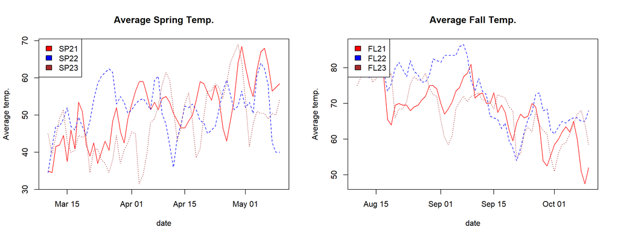

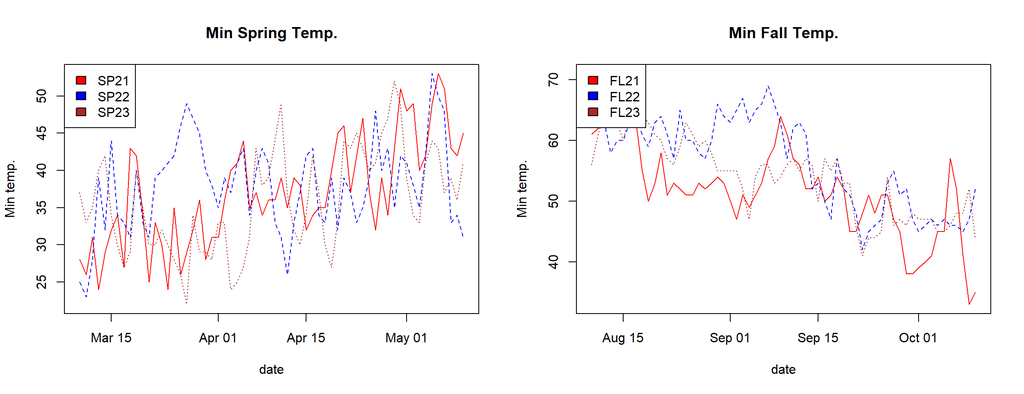

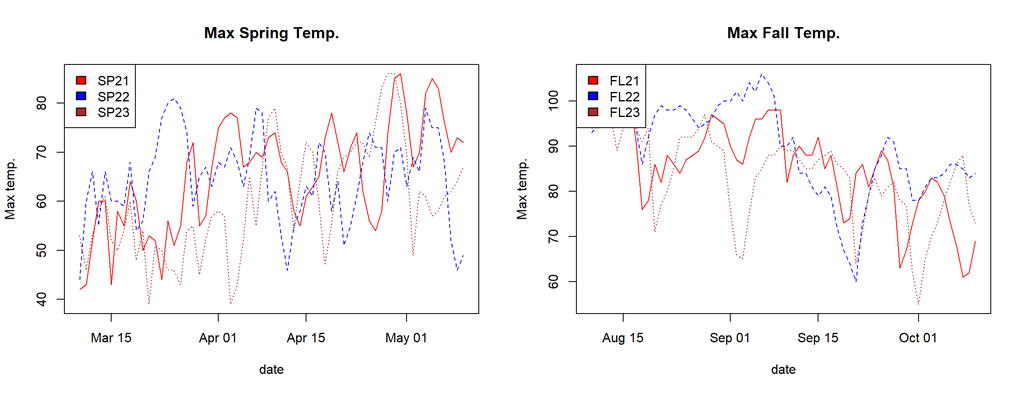

## Week 1 Temperature Analysis

### Stats

ANOVA Spring week 1 - TEMP_AVERAGE ~ factor(YEAR)

|  | Df | Sum Sq | Mean Sq | F value | Pr(>F) |
| --- | --- | --- | --- | --- | --- |
| factor(YEAR) | 2 | 618.4524 | 309.2262 | 7.273873 | 0.0048391 |
| Residuals | 18 | 765.2143 | 42.5119 | NA | NA |

Tukey Spring week 1 - ANOVA(TEMP_AVERAGE ~ factor(YEAR))

|  | diff | lwr | upr | p adj |
| --- | --- | --- | --- | --- |
| 2022-2021 | -7.857143 | -16.75181 | 1.037524 | 0.0888148 |
| 2023-2021 | -13.214286 | -22.10895 | -4.319619 | 0.0036348 |
| 2023-2022 | -5.357143 | -14.25181 | 3.537524 | 0.2978214 |

ANOVA Spring week 1 - TEMP_MAX ~ factor(YEAR)

|  | Df | Sum Sq | Mean Sq | F value | Pr(>F) |
| --- | --- | --- | --- | --- | --- |
| factor(YEAR) | 2 | 1245.81 | 622.90476 | 8.787058 | 0.0021739 |
| Residuals | 18 | 1276.00 | 70.88889 | NA | NA |

Tukey Spring week 1 - ANOVA(TEMP_MAX ~ factor(YEAR))

|  | diff | lwr | upr | p adj |
| --- | --- | --- | --- | --- |
| 2022-2021 | -11.428571 | -22.91443 | 0.057288 | 0.0512770 |
| 2023-2021 | -18.714286 | -30.20015 | -7.228426 | 0.0016276 |
| 2023-2022 | -7.285714 | -18.77157 | 4.200145 | 0.2635155 |

**P = 0.00217, significant, 2021 is different with 90% sig level**

ANOVA Spring week 1 - TEMP_MIN ~ factor(YEAR)

|  | Df | Sum Sq | Mean Sq | F value | Pr(>F) |
| --- | --- | --- | --- | --- | --- |
| factor(YEAR) | 2 | 209.1429 | 104.5714 | 2.904762 | 0.080667 |
| Residuals | 18 | 648.0000 | 36.0000 | NA | NA |

Tukey Spring week 1 - ANOVA(TEMP_MIN ~ factor(YEAR))

|  | diff | lwr | upr | p adj |
| --- | --- | --- | --- | --- |
| 2022-2021 | -4.285714 | -12.47085 | 3.8994172 | 0.3941497 |
| 2023-2021 | -7.714286 | -15.89942 | 0.4708458 | 0.0666534 |
| 2023-2022 | -3.428571 | -11.61370 | 4.7565601 | 0.5446789 |

**P = 0.0807, NOT significant, 2023-2021 is different**

ANOVA Fall week 1 TEMP_AVERAGE ~ factor(YEAR)

|  | Df | Sum Sq | Mean Sq | F value | Pr(>F) |
| --- | --- | --- | --- | --- | --- |
| factor(YEAR) | 2 | 487.1667 | 243.58333 | 12.04297 | 0.0004789 |
| Residuals | 18 | 364.0714 | 20.22619 | NA | NA |

Tukey Fall week 1 - ANOVA(TEMP_AVERAGE ~ factor(YEAR))

|  | diff | lwr | upr | p adj |
| --- | --- | --- | --- | --- |
| 2022-2021 | -5.428571 | -11.56381 | 0.7066672 | 0.0881956 |
| 2023-2021 | -11.785714 | -17.92095 | -5.6504757 | 0.0003220 |
| 2023-2022 | -6.357143 | -12.49238 | -0.2219042 | 0.0415794 |

**P < 0.05, P = 0.000479, significant, 2023 is different**

ANOVA Fall week 1 TEMP_MAX ~ factor(YEAR)

|  | Df | Sum Sq | Mean Sq | F value | Pr(>F) |
| --- | --- | --- | --- | --- | --- |
| factor(YEAR) | 2 | 1469.2381 | 734.61905 | 14.39533 | 0.0001845 |
| Residuals | 18 | 918.5714 | 51.03175 | NA | NA |

Tukey Fall week 1 Max - ANOVA(TEMP_MAX ~ factor(YEAR))

|  | diff | lwr | upr | p adj |
| --- | --- | --- | --- | --- |
| 2022-2021 | -8.857143 | -18.60243 | 0.888144 | 0.0785563 |
| 2023-2021 | -20.428571 | -30.17386 | -10.683285 | 0.0001240 |
| 2023-2022 | -11.571429 | -21.31672 | -1.826142 | 0.0187604 |

**P = 0.000185 significant, 2023 is different**

ANOVA Fall week 1 TEMP_MIN ~ factor(YEAR)

|  | Df | Sum Sq | Mean Sq | F value | Pr(>F) |
| --- | --- | --- | --- | --- | --- |
| factor(YEAR) | 2 | 35.42857 | 17.714286 | 1.910959 | 0.1767732 |
| Residuals | 18 | 166.85714 | 9.269841 | NA | NA |

Tukey Fall week 1 Min - ANOVA(TEMP_MIN ~ factor(YEAR))

|  | diff | lwr | upr | p adj |
| --- | --- | --- | --- | --- |
| 2022-2021 | -2.000000 | -6.153465 | 2.153465 | 0.4520604 |
| 2023-2021 | -3.142857 | -7.296322 | 1.010608 | 0.1587432 |
| 2023-2022 | -1.142857 | -5.296322 | 3.010608 | 0.7652385 |

**P = 0.177 NOT significant, All same**

### Plots

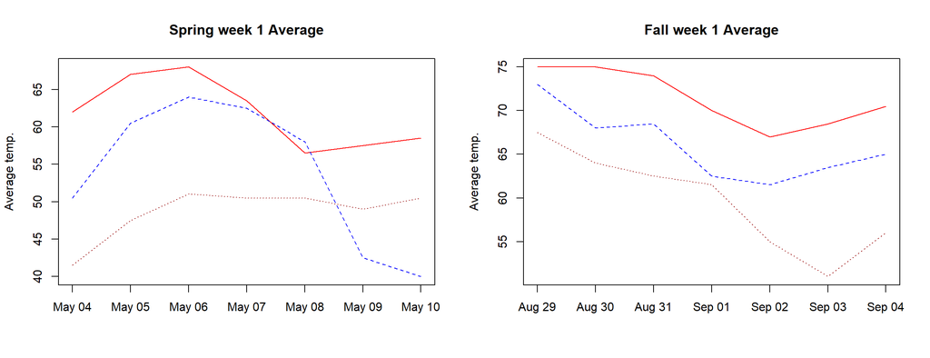

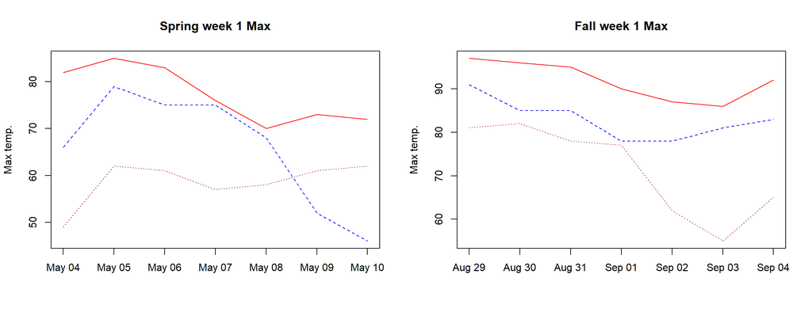

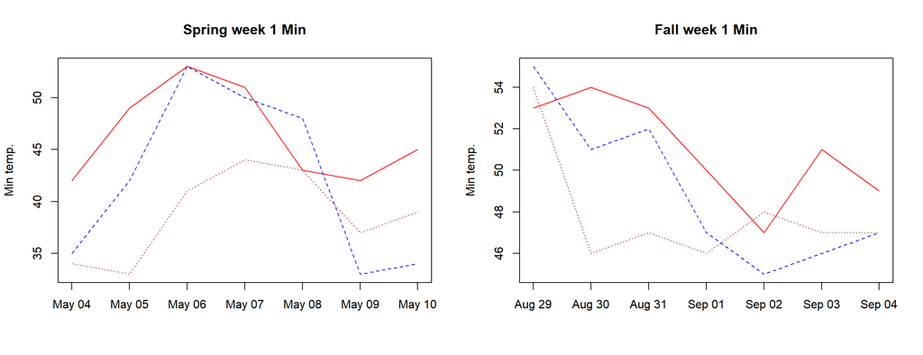

## Conclusion

Our temperature analysis reveals that Spring 2023 was significantly colder than previous years, with average and maximum temperatures showing a notable decline, particularly in Week 1. This suggests that spring species were impacted by colder temperatures and (in conjunction with the snow fall analysis) heavy snowfall, likely delaying growth. As spring bloomers are more sensitive to winter conditions, variation in nighttime low temperatures and soil moisture retention from slow snowmelt could explain the shifts in bloom timing and species. However, our analysis did not identify clear trends between temperature and total plant volume across years, suggesting that there may be an ecological threshold where additional moisture does not always lead to increased plant germination and growth. In contrast, fall temperatures fluctuated, with 2022 being significantly warmer than both 2021 and 2023, yet these variations did not disrupt fall bloom patterns. Since fall species are more adapted to germinating in harsh conditions—including high temperatures and low precipitation—their bloom cycles appear more consistent despite annual shifts in seasonal climate variables. These findings support the idea that spring bloomers experience more variability in response to weather patterns, whereas fall species exhibit greater resilience to changing environmental conditions.